# MSTExam

2024-05-01

```r
data <- read.csv("C:/Users/ishita/Downloads/MSTE.csv",header = TRUE)
print(data)
```

```
##      X1   X2      X3   X4   X5    X6   X7    X8
## 1  1.06  9.2  151.00 54.4  1.6  9077  0.0 0.628
## 2  0.89 10.3  202.00 57.9  2.2  5088 25.3 1.555
## 3  1.43 15.4  113.00 53.0  3.4  9212  0.0 1.058
## 4  1.02 11.2  168.00 56.0  0.3  6423 34.3 0.700
## 5  1.49  8.8    1.92 51.2  1.0  3300 15.6 2.044
## 6  1.32 13.5  111.00 60.0 -2.2 11127 22.5 1.241
## 7  1.22 12.2  175.00 67.6  2.2  7642  0.0 1.652
## 8  1.10  9.2  245.00 57.0  3.3 13082  0.0 0.309
## 9  1.34 13.0  168.00 60.4  7.2  8406  0.0 0.862
## 10 1.12 12.4  197.00 53.0  2.7  6455 39.2 0.623
## 11 0.75  7.5  173.00 51.5  6.5 17441  0.0 0.768
## 12 1.13 10.9  178.00 62.0  3.7  6154  0.0 1.897
## 13 1.15 12.7  199.00 53.7  6.4  7179 50.2 0.527
## 14 1.09 12.0   96.00 49.8  1.4  9673  0.0 0.588
## 15 0.96  7.6  164.00 62.2 -0.1  6468  0.9 1.400
## 16 1.16  9.9  252.00 56.0  9.2 15991  0.0 0.620
## 17 0.76  6.4  136.00 61.9  9.0  5714  8.3 1.920
## 18 1.05 12.6  150.00 56.7  2.7 10140  0.0 1.108
## 19 1.16 11.7  104.00 54.0 -2.1 13507  0.0 0.636
## 20 1.20 11.8  148.00 59.9  3.5  7279 41.1 0.702
## 21 1.04  8.6  204.00 61.0  3.5  6650  0.0 2.116
## 22 1.07  9.3 1784.00 54.3  5.9 10093 26.6 1.306
```

```r
library(dplyr)
library(cluster)
```

We carry out hierarchical clustering by both methods:Agglomerative and Divisive.

Agglomerative Clustering

```r
Agg_clust <- agnes(data)
Agg_clust$ac
```

```
## [1] 0.9067418
```

We get the Agglomerative coefficient to be 0.9067418 which is close to 1.So our clustering algorithm does a good job of clustering.

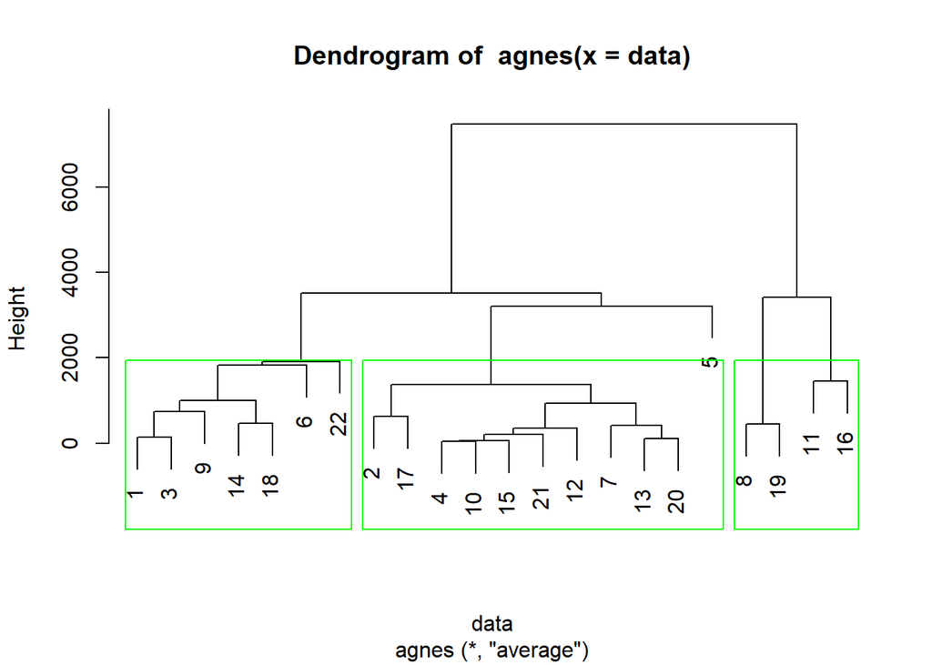

```r
pltree(Agg_clust)
Aclust <- cutree(Agg_clust,k=3)
rect.hclust(Agg_clust,k = 3, border = "green")
```

Divisive Clustering

```r
Div_clust <- diana(data)
Div_clust$dc
```

```
## [1] 0.9427349
```

We get the Divisive coefficient to be 0.9427349 which is close to 1.So our clustering algorithm does a good job of clustering.

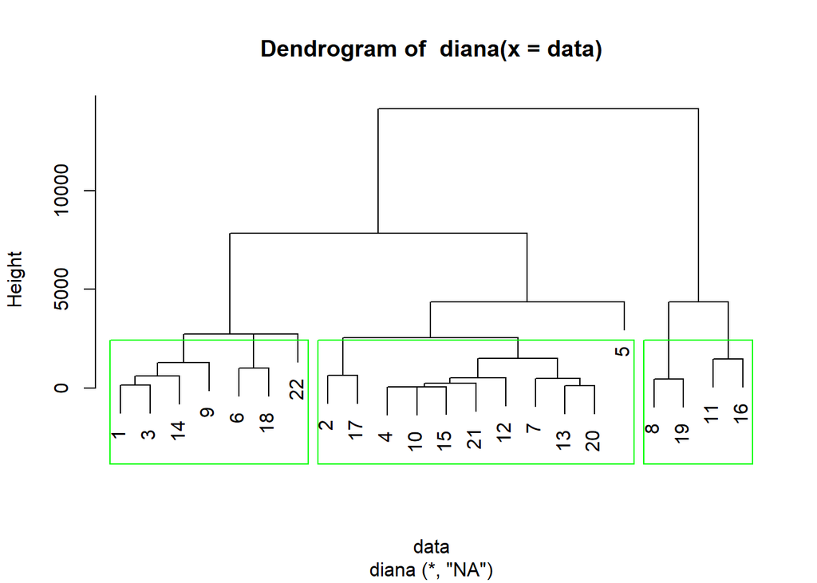

```r
pltree(Div_clust)
Dclust <- cutree(Div_clust,k=3)
rect.hclust(Div_clust,k = 3, border = "green")
```

After looking at both the divisive and agglomerative clustering,we conclude that divisive clustering is better because it has higher clustering coefficient.

K-Means clustering K-means clustering with K = 4.

```r
set.seed(1234)
km4 <- kmeans(data,centers = 4,nstart = 25)
km4
```

```
## K-means clustering with 4 clusters of sizes 11, 2, 2, 7
##
## Cluster means:
##         X1       X2       X3       X4       X5        X6        X7        X8
## 1 1.089091 10.26364 161.1745 58.76364 3.127273  6213.818 19.536364 1.3760000
## 2 1.130000 10.45000 174.5000 55.50000 0.600000 13294.500  0.000000 0.4725000
## 3 0.955000  8.70000 212.5000 53.75000 7.850000 16716.000  0.000000 0.6940000
## 4 1.194286 12.14286 367.5714 55.51429 2.857143  9675.429  7.014286 0.9701429
##
## Clustering vector:
##  [1] 4 1 4 1 1 4 1 2 4 1 3 1 1 4 1 3 1 4 2 1 1 4
##
## Within cluster sum of squares by cluster:
## [1] 14510830.6   100275.3  1054387.2  7027360.4
##  (between_SS / total_SS =  91.5 %)
##
## Available components:
##
## [1] "cluster"      "centers"      "totss"        "withinss"     "tot.withinss"
## [6] "betweenss"    "size"         "iter"         "ifault"
```

K-means clustering with K = 5.

```r
set.seed(1234)
km5 <- kmeans(data,centers = 5,nstart = 25)
km5
```

```
## K-means clustering with 5 clusters of sizes 2, 2, 2, 7, 9
##
## Cluster means:
##         X1       X2       X3       X4       X5        X6        X7        X8
## 1 1.190000  9.55000 101.9600 54.55000 1.600000  4194.000 20.450000 1.7995000
## 2 1.130000 10.45000 174.5000 55.50000 0.600000 13294.500  0.000000 0.4725000
## 3 0.955000  8.70000 212.5000 53.75000 7.850000 16716.000  0.000000 0.6940000
## 4 1.194286 12.14286 367.5714 55.51429 2.857143  9675.429  7.014286 0.9701429
## 5 1.066667 10.42222 174.3333 59.70000 3.466667  6662.667 19.333333 1.2818889
##
## Clustering vector:
##  [1] 4 1 4 5 1 4 5 2 4 5 3 5 5 4 5 3 5 4 2 5 5 4
##
## Within cluster sum of squares by cluster:
## [1] 1618559.6  100275.3 1054387.2 7027360.4 2911131.3
##  (between_SS / total_SS =  95.2 %)
##
## Available components:
##
## [1] "cluster"      "centers"      "totss"        "withinss"     "tot.withinss"
## [6] "betweenss"    "size"         "iter"         "ifault"
```

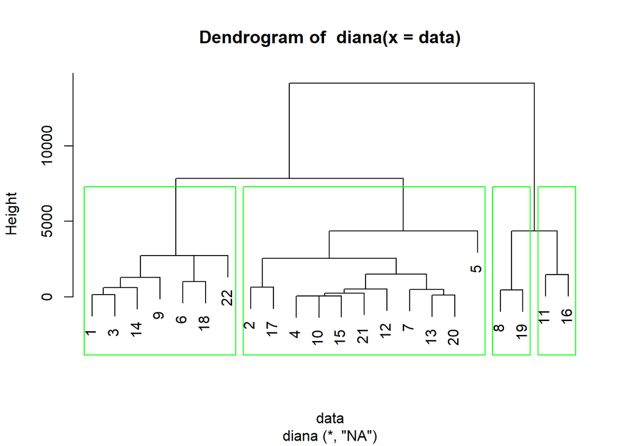

```r
pltree(Div_clust)
Dclust <- cutree(Div_clust,k=4)
rect.hclust(Div_clust,k = 4, border = "green")
```

On using the Divisive algorithm to make 4 clusters,we get the sizes of clusters as 7,11,2,2.This split is same as K-Means clustering.

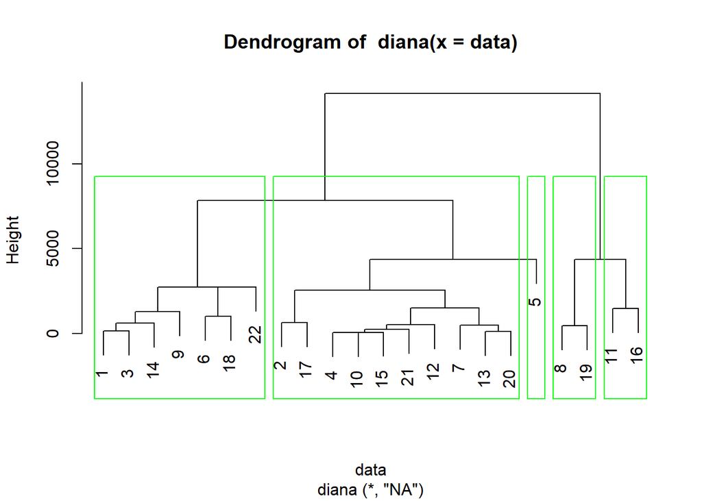

```r
pltree(Div_clust)
Dclust <- cutree(Div_clust,k=5)
rect.hclust(Div_clust,k = 5, border = "green")
```

On using the Divisive algorithm to make 5 clusters,we get the sizes of clusters as 7,10,1,2,2.This split is a bit different than K-Means clustering.

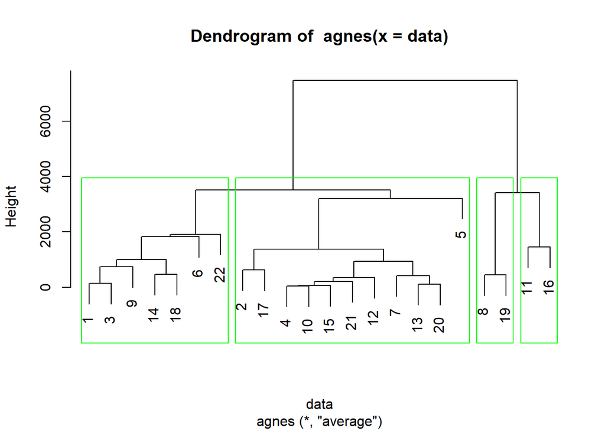

```r
pltree(Agg_clust)
Aclust <- cutree(Agg_clust,k=4)
rect.hclust(Agg_clust,k = 4, border = "green")
```

On using the Agglomerative algorithm to make 4 clusters,we get the sizes of clusters as 7,11,2,2.This split is same as K-Means clustering.

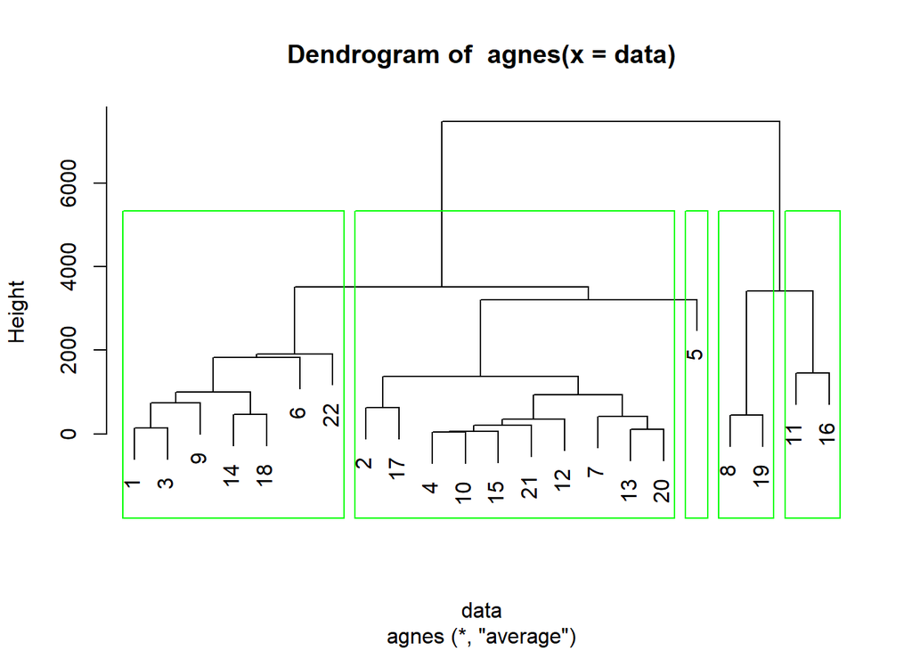

```r
pltree(Agg_clust)
Aclust <- cutree(Agg_clust,k=5)
rect.hclust(Agg_clust,k = 5, border = "green")
```

On using the Agglomerative algorithm to make 5 clusters,we get the sizes of clusters as 7,10,1,2,2.This split is a bit different than K-Means clustering.

So as both the hierarchical algorithms give the same classification for k=4 and k=5,we can’t differentiate based on this.

So we will prefer the divisive hierarchical algorithm as the clustering coefficient for this algorithm is greater.

We now carry out PCA on our data. We first scale our data,so that no variable dominates our results because of high variance values.

```r
scaled_data <- as.data.frame(scale(data))
sapply(scaled_data,mean)
```

```
##            X1            X2            X3            X4            X5
##  4.128642e-16 -1.877641e-18  9.422703e-18  7.650525e-17  7.222758e-17
##            X6            X7            X8
##  4.067237e-17  3.530557e-17 -9.791208e-17
```

```r
sapply(scaled_data, sd)
```

```
## X1 X2 X3 X4 X5 X6 X7 X8
##  1  1  1  1  1  1  1  1
```

```r
data.pca <- prcomp(scaled_data)
summary(data.pca)
```

```
## Importance of components:
##                           PC1    PC2    PC3    PC4     PC5     PC6     PC7
## Standard deviation     1.4345 1.3821 1.1591 0.9589 0.85998 0.78135 0.48921
## Proportion of Variance 0.2572 0.2388 0.1679 0.1149 0.09245 0.07631 0.02992
## Cumulative Proportion  0.2572 0.4960 0.6640 0.7789 0.87134 0.94765 0.97757
##                            PC8
## Standard deviation     0.42363
## Proportion of Variance 0.02243
## Cumulative Proportion  1.00000
```

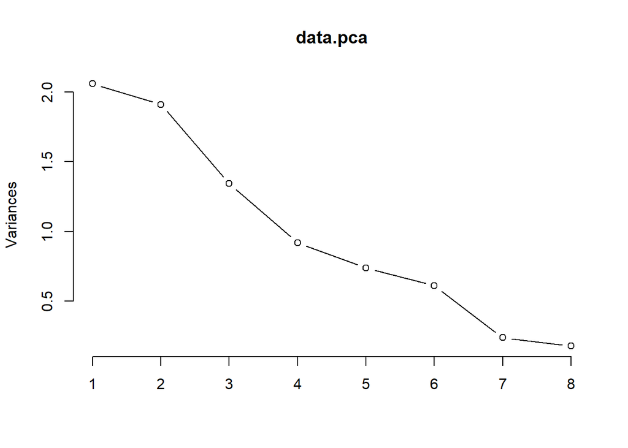

```r
screeplot(data.pca,type = "lines")
```

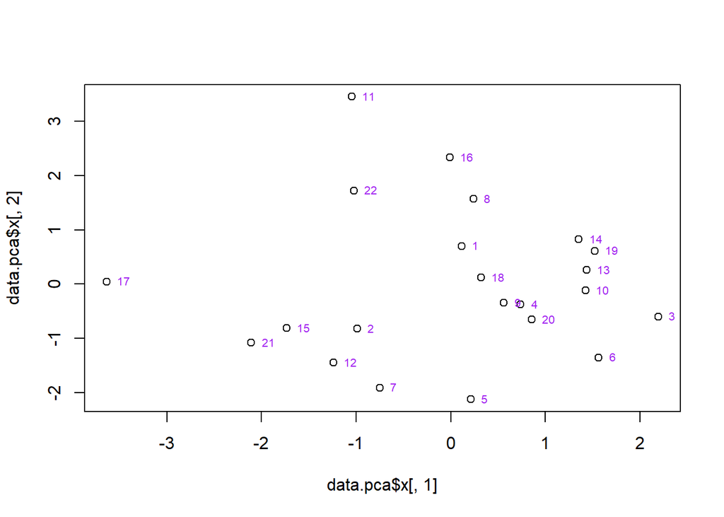

```r
plot(data.pca$x[,1],data.pca$x[,2])
text(data.pca$x[,1],data.pca$x[,2],cex = 0.65,pos = 4, col = "purple")
```

We plot the first two components obtained after PCA.

We will compare the results of PCA with hierarchical clustering. The points 14,13,19,10 are close by in the plot but they actually belong to different clusters.

The points 11,16 which are in the same cluster have higher values of component 2.

The points in cluster 1 which are 1,3,14,9,6,18,22 have higher values of component 1 except for 22.

Points in cluster 2 look like points having lower values of component 2.

Conclusion : Divisive algorithm for hierarchial clustering fits better for this dataset.The results given by K-Means clustering and Hierarchial clustering are similar for k=4,but differ a bit for k=5.On adopting PCA on the dataset,we see that some of the results of clustering are explainable using the principal components but some results are different.